# 05_3_A_TS_BoxCox_Transformation

# Libraries

```r
library(fpp3)
```

# References

1. Hyndman, R.J., & Athanasopoulos, G., 2021. Forecasting: principles and practice. 3rd edition.

# Note:

This notebook is not original material, but rather an expansioon of reference 1 (which is publicly available) with additional comments and explanations given by the professor to help students understand the concepts.

# Mathematical transformations

The transformations we are going to use in the context of time series are **useful**:

1. If the data shows **variation that increases or decreases with the level of the series**. That is, if it is multiplicative to a certain extent.
2. If the data is a simple exponential trend they can help linearize it (at the cost of interpretability).

Notation:

## log() transformations

$$\begin{align*}
\boxed{w_t = log(y_t)}
\end{align*}$$

**NOTE:** the **log** function returns the **natural logarithm**. Natural logarithms (base $e$) are actually the reference for the rest of the logarithms. There are multiple reasons for this (beyond the scope of this course), the main one being that the derivative of $e^x$ is actually $e^x$. This has very important implications, particularly in the field of differential equations (general culture comment, beyond the scope of this course).

As a reminder of the properties of logarithms, **you should be comfortable enough with the basic properties of lograithms that you are able to always easily derive these two equations**. It is not necessary for this course but being able to prove those two statements would help you refresh your logarithm algebra (left for the student who wants to devote some time to this):

- $a^x = e^{xLn(a)}$
- $log_a(x) = \frac{log_b(x)}{log_b(a)}$

### Interpretation of logarithms

Changes in a log value are relative (or percentage changes) on the original scale. Example with log 10:

- An increase of 1 on the $log_{10}$ scale corresonds to multiplying by 10 on the original scale.

We do not have time to see this in class and this should already have been clarified to you by other professors (particularly by those giving you Data Visualisation). I will upload a video to blackboard covering this.

### Transformation $log(1+x)$

**If the data contains either zeros or negative values, logarithms are not possible, since the real logarithm is only defined for** $x > 0$.

**If the data contains zeros and no negative values, then the transformation** $log(1+x)$ can be useful:

- $log(1+x)$ can be useful for data with zeros that we feel would benefit from a log transformation. You can use the function `log1p()` directly for this:

**Question** can anybody tell me why this transformation is good when we have data with zeros? Specifically why $1$ and no other constant is chosen:

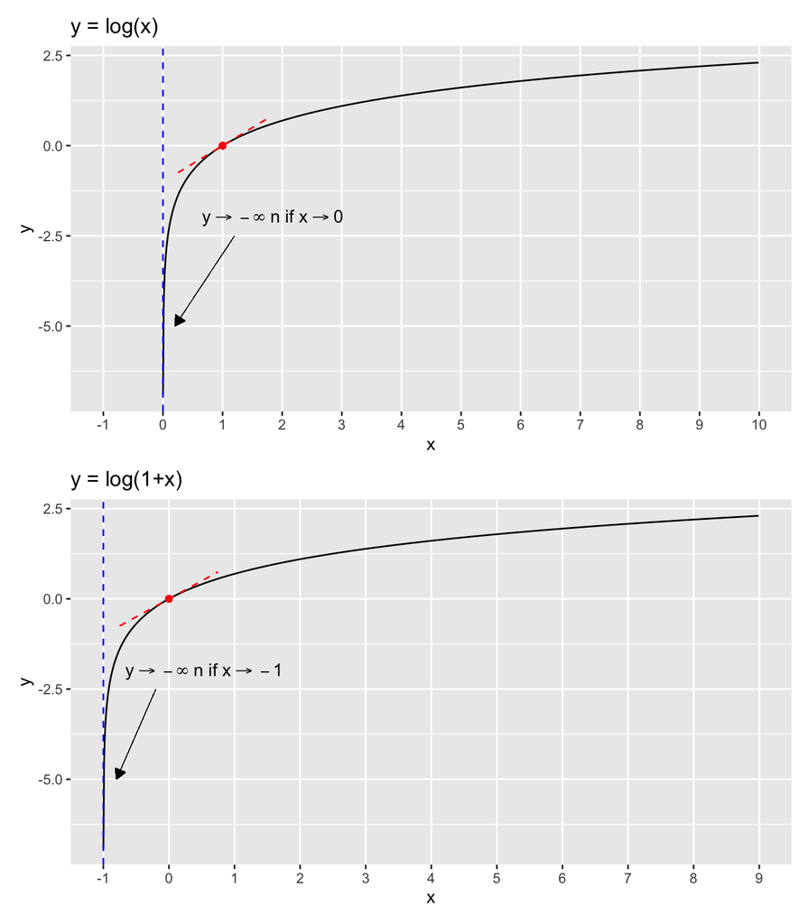

## Power transformations

$$\begin{align*}
w_t = y_t^p
\end{align*}$$

They are not as interpretable as the logarithmic transformation. They also tend to stabilize seasonal variations, as we saw in the example of the adiabatic anti-drug sales (see the introductory session to time series decomposition, where the concept of additive vs multiplicative schemes is introduced).

## Box-Cox transformations

This transformation includes both logarithms and power transformations. They depend on the parameter $\lambda$.

$$\begin{equation}
w_t =
\begin{cases}
\log(y_t) & \text{if $\lambda=0$}; \\
(\text{sign}(y_t)|y_t|^\lambda-1)/\lambda & \text{otherwise}.
\end{cases}
\end{equation}$$

**Question:** what is the difference between a variable and a parameter?

The Box-Cox transformation also attempts to stabilize the seasonal fluctuations and random variations. Specifically, **it addresses cases where the variance of the time series grows with the level of the series*

The following [link](https://otexts.com/fpp3/transformations.html#mathematical-transformations) leads to an interactive graph that clarifies the effect of $\lambda$ on the box-cox transformation in the context of time series.

- The logarithm in a Box-Cox transformation is **always a natural logarithm**.
  - $\lambda = 1$: no substantial transformation. Data is simply shifted downwards. ($w_t = y_t -1$)
  - $\lambda = 0$: transformation equivalent to a natural logarithm.
  - $\lambda = 1/2$: Square root + scaling transformation
  - $\lambda = 1/3$: Cubic root + scaling transformation
  - $\lambda = -1$: Inverse transformation (+ 1)
- **Considerations when using this transformation**`
  - **If some data are zero or negative, use** $\lambda > 0$, since the real logarithm is not defined in this case.
  - Always check your results depicting the time series.
  - A **low value of** $\lambda$ can result in extremely large prediction intervals.
  - **If the best value of** $\lambda$ is very close to 0, it is *preferable to use a log transformation* because it has *much better interpretability*.
  - The **final judge of the transformation** will be the **performance of the model you are trying to use** and the **uncertainty associated to its predicions** (prediction intervals). This is very important. Throughout the course we will learn how to evaluate the performance of our models.

### Caveat of Box-Plot like transformations

Power transformations (such as the box-plot transformation) **require the variability of the series to vary proportionally to the level of the series**.

Let us look at data about the production of gas in Canada:

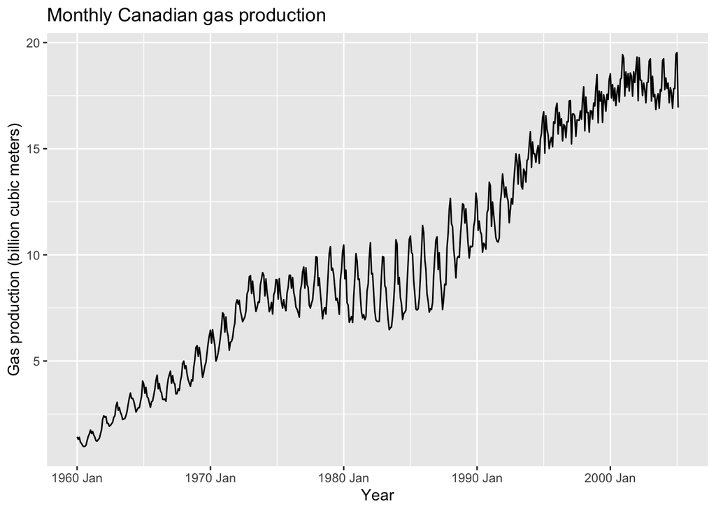

```r
canadian_gas %>%
  autoplot(Volume) +
  labs(
    x = "Year", y = "Gas production (billion cubic meters)",
    title = "Monthly Canadian gas production"
  )
```

- The **variation of the series is not proportional to the amount of gas produced in Canada.**
  - **For small and large production levels:** small variations in the seasonal pattern
  - **Moderate production leveks:** between 1975 and 1990. The variation in the seasonal pattern is large.

In this case the box-cox transformation would not be of much help to render the variance of the seasonal component independnet from the level of the series.

### Guerrero feautre to pick a variable for the parameter lambda

The Guerrero feature suggest a value of lambda that results in the best Box-Cox transformation to make the scheme of the series additive. Like everything It does not work 100%, but for most cases it will result in a good value to render the scheme of the series additive.

Let us look at the gas production in Australia:

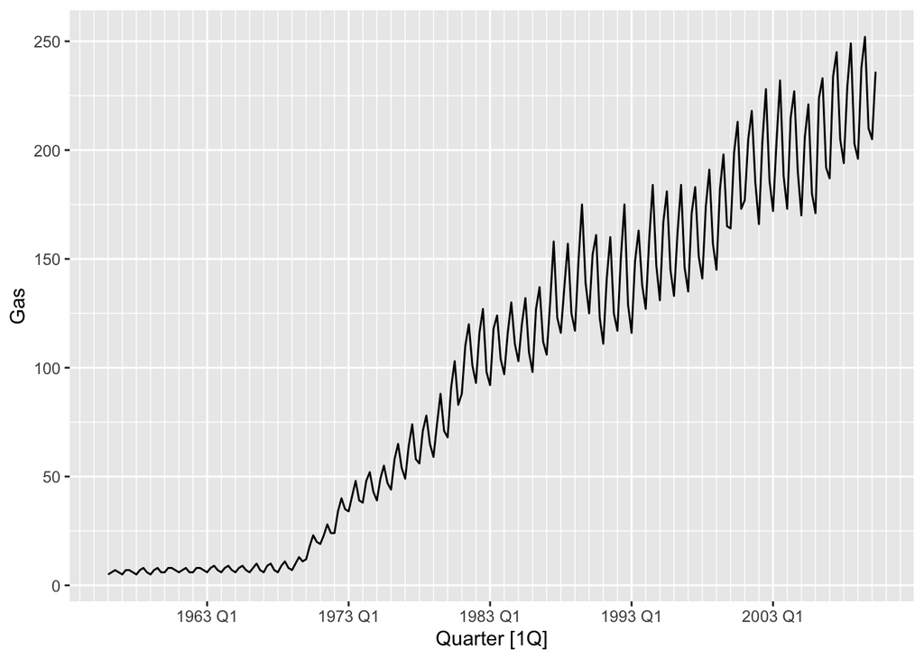

```r
aus_production %>%
  autoplot(Gas) +
  scale_x_yearquarter(
    breaks = "10 years",
    minor_breaks = "1 year"
  )
```

In the example below we apply it to the `Gas` time series within the dataset `aus_production`, loaded along with `fpp3`.

```r
lambda <- aus_production %>%
  features(Gas, features = guerrero) %>%
  pull(lambda_guerrero)

lambda
```

```
[1] 0.1095171
```

The suggested value of lambda is 0.1, which is neither too close to 0 (log) or 1 (no transformation). So in principle we will apply the box-cox transformation.

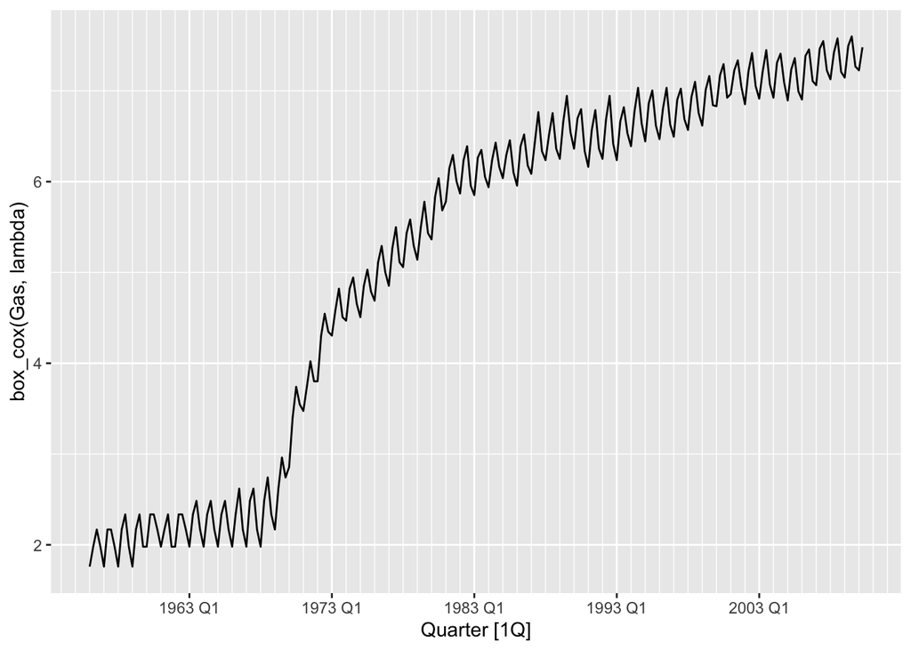

```r
aus_production %>%
  autoplot(box_cox(Gas, lambda)) +
  scale_x_yearquarter(
    breaks = "10 years",
    minor_breaks = "1 year"
  )
```

### Usual wrokflow with the box-cox tranformation

If you decide that a box-cox transformation could be of help for the case at hand, the flowchart below is a general outline of the process:

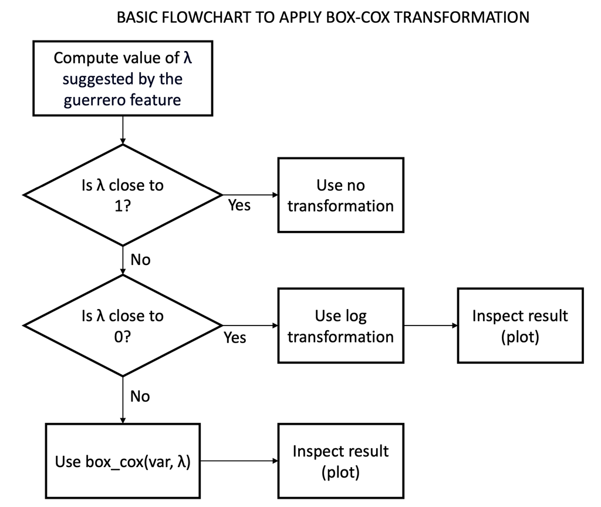

1. Check the value of lambda suggested by the `guerrero` feature.
2. If the value of lambda is very close to 1, do not apply a transformation, since the Box-Cox transformation will barely have a noticeable effect yet do away with the interpretability of the variable.
3. If the value of lambda is very close to 0, apply a $log()$ transformation instead, since their effect will be very close and the log transformation preserves the interpretability.
4. If the value of lambda is neither close to 0, nor close to 1, apply the Box-cox transformation.

In the end, **always check the result creating a timeplot of the data**. You may also add some quantitative metrics as the moving standard deviation (not done in this course) to help you understand if the variance increases with the level of the series after the transforamtions or if it has been stabilized.

The exercises and homework at the end of the notebook will bring clarity to this process.

## Advanced - other transformations for data with 0s or negative values

The following [article](https://robjhyndman.com/hyndsight/transformations/) is worth reading. This is beyond the scope of the course, but it is a good reference if you ever face this issue.

## Some notes on transformations

- **Often no transformation is needed** and we are able to produce a good forecast with the original data. **Do not transform just for the sake of transforming**, the end goal is to **make data more palatable for a model so that it improves its performance**.
  - The **final judge of the transformation** will be the **performance of the model you are trying to use** and the **uncertainty associated to its predicions** (prediction intervals). This is very important. Throughout the course we will learn how to evaluate the performance of our models.
- Transformations that have good interpretability (such as log transformations) are preferred if they work well enough.
- Transformations **can have a very large effect on Prediction Intervals**.
- Transformations **must be reversed to obtain forecasts on the original scale**.

# Examples

For each of the following series, make a graph of the data. If transforming seems appropriate, do so and describe the effect.

```r
retail_series <- aus_retail %>%
  filter(`Series ID` == "A3349767W")
```

### Example 1. United states gdp from global economy:

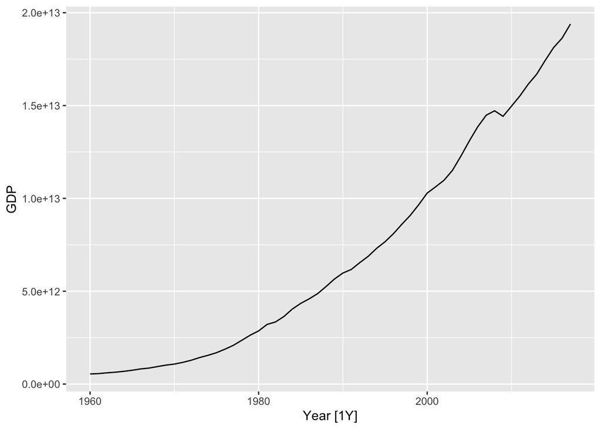

```r
us_economy <- global_economy %>%
  filter(Country == "United States")
us_economy %>%
  autoplot(GDP)
```

In the graph above, the derivative increases with the level of the series (the derivative is the slope of the tangent tangent to the graph at each point). This is **another form of increasing variance with the level of the series**, a non-linear trend. The box-cox transformation is also useful to address this.

### Example 2. Slaughter of Victorian “Bulls, bullocks and steers”

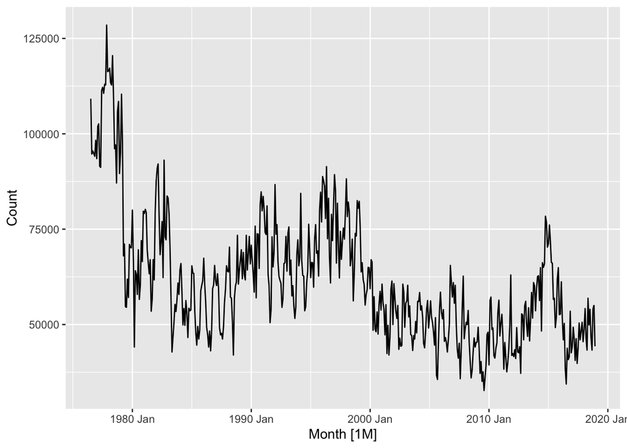

```r
vic_bulls <- aus_livestock %>%
  filter(State == "Victoria", Animal == "Bulls, bullocks and steers")
vic_bulls %>%
  autoplot(Count)
```

### Example 3. Tobacco from aus_production

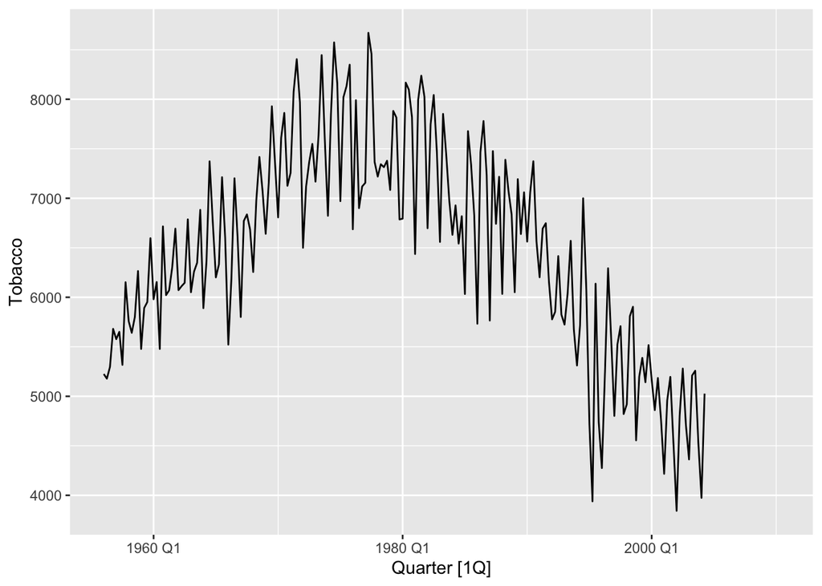

```r
aus_production %>%
  autoplot(Tobacco)
```

### Example 4. Retail series

```
Plot variable not specified, automatically selected `.vars = Turnover`
```

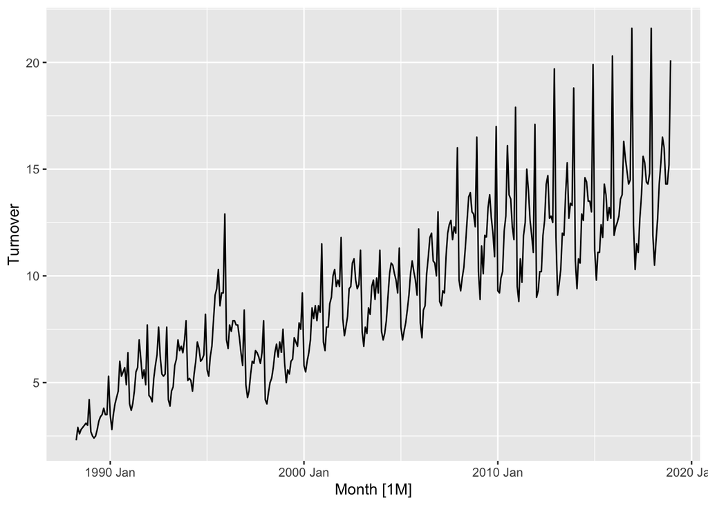

```r
retail_series <- aus_retail %>%
  filter(`Series ID` == "A3349767W")

autoplot(retail_series)
```

# Homework

**NOTE:** For these exercises you need separate datasets that will be uploaded to blackboard. You need the library `readr` as well to read csv files with the function `read_csv``

Judge if one of the mathematical transformations explained in class is sensible or not.

If so, specify which transformation you have chosen and provide adequate justification

## Exercise 1 - Australian imports from Japan

The code below imports the data contained in the file *australian_imports_japan.csv*, which is located in the folder *ZZ_Datasets* in google drive. When you run the code, **a pop-up window will prompt you to select the .csv file** and import the data.

The following is a plot of the data.

```r
aus_import_japan <-
  readr::read_csv(file.choose()) %>%
  mutate(index=yearmonth(index)) %>%
  as_tsibble()

aus_import_japan %>%
  autoplot() +
  labs(x = "year-month",
       y = "Australian imports from Japan (thousands $)")
```

```
Plot variable not specified, automatically selected `.vars = value`
```

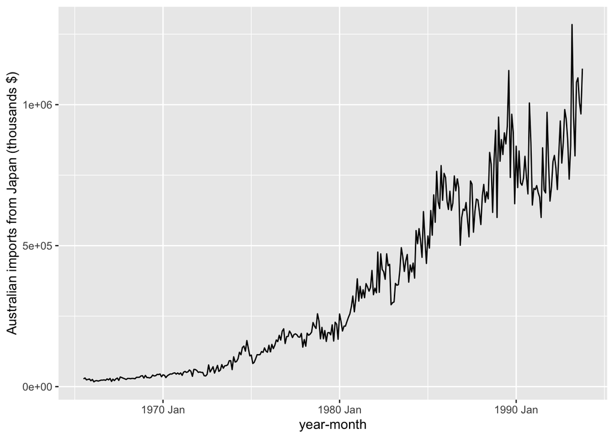

## Exercise 2 - Private housing units started - USA

The code below imports the data contained in the file *private_housing_US.csv*, which is located in the folder *ZZ_Datasets* in google drive. When you run the code, **a pop-up window will prompt you to select the .csv file** and import the data.

The following is a plot of the data.

```r
private_housing_Us <-
  readr::read_csv(file.choose()) %>%
  mutate(index=yearmonth(index)) %>%
  as_tsibble()

autoplot(private_housing_Us) +
labs(x = "year-month",
     y = "Private housing units started, USA: monthly")
```

```
Plot variable not specified, automatically selected `.vars = value`
```

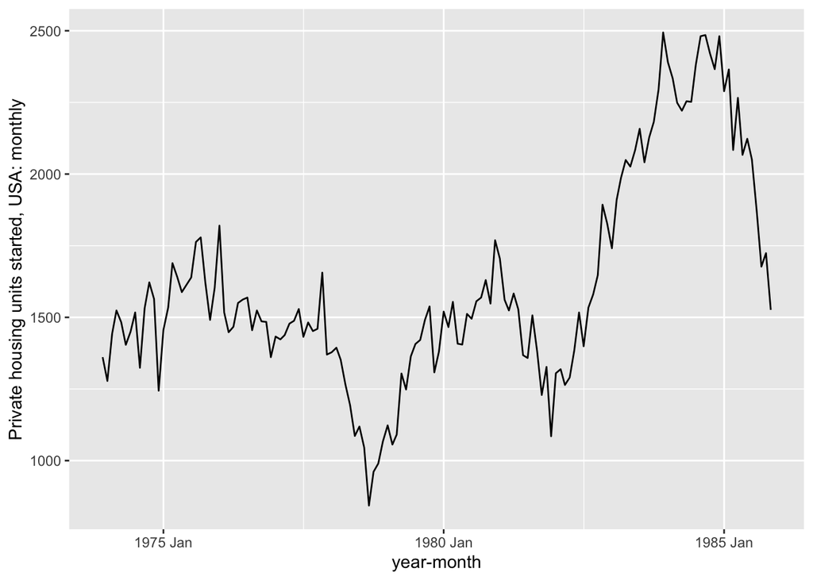